# MPW Tidepool Water Column Metabolism

- Show All Code
- Hide All Code
- View Source

Project notebook: field notes, respirometry processing, QC and early results

Author

Jordan Vest

Published

October 27, 2026

```r
library(tidyverse)
library(here)
library(knitr)

# ---- load everything this notebook uses (all made by the scripts, nothing is calculated from raw files here) ----
SampleMeta <- read_csv(here("data", "mpw_sample_meta.csv"))                          # one row per sample: field + lab data
RespoMeta  <- read_csv(here("data", "respirometry", "mpw", "mpw_respo_meta.csv"))    # respo times, notes, exclude
RespoR_PR  <- read_csv(here("data", "respirometry", "mpw", "processed", "mpw_PnR_rates.csv")) # rates from respo_rates_plots.R

# samples left out of results = anything with text in the "exclude" column
excluded <- RespoMeta %>% filter(!is.na(exclude)) %>% distinct(sample_ID, exclude)

# which instrument each chamber channel belongs to
device_of <- function(ch) case_when(ch %in% 1:4   ~ "Oxy-4 #087 (ch 1-4)",
                                    ch %in% 5:8   ~ "Oxy-4 #082 (ch 5-8)",
                                    ch %in% 9:12  ~ "Oxy-4 #100 (ch 9-12)",
                                    ch %in% 13:22 ~ "Oxy-10 (ch 13-22)")
```

## 1. Overview

**Question:** How does water column metabolism (respiration and photosynthesis of the plankton community) change across a groundwater gradient at the Kapo’o tidepool at Shark’s Cove?

**Site:** Kapo’o tidepool, North Shore of Oʻahu. The tidepool is shallow and lagoon-like (max ~4 ft deep). It receives submarine groundwater discharge (SGD) linked to the beach restroom, which is likely carrying sewage. Samples were also taken outside the pool in the adjacent cove and ocean.

**Design:** 6 sampling days (Oct 1–6, 2026). Each day at dawn, one sampler collected 10 samples inside the pool and one collected 10 outside (5 cove, 5 ocean), plus one blank. Each sample was split into subsamples for respirometry, chl-a, nutrients, fDOM, flow cytometry (FCM) and total alkalinity (TA).

**Respirometry:** PreSens Oxy-4 (×3) and Oxy-10, 473 mL chambers

Collaborator: Mālama Pūpūkea-Waimea (MPW) Field Team: …

## 2. Field collection

```r
SampleMeta %>%
  count(day, date, habitat) %>%
  pivot_wider(names_from = habitat, values_from = n, values_fill = 0) %>%
  mutate(total = lagoon + cove + ocean + blank) %>%
  kable(caption = "Samples collected per day and habitat")
```

Samples collected per day and habitat

| day | date | blank | cove | lagoon | ocean | total |
| --- | --- | --- | --- | --- | --- | --- |
| 1 | 2026-10-01 | 1 | 5 | 10 | 5 | 21 |
| 2 | 2026-10-02 | 1 | 5 | 10 | 5 | 21 |
| 3 | 2026-10-03 | 1 | 5 | 10 | 5 | 21 |
| 4 | 2026-10-04 | 1 | 5 | 10 | 5 | 21 |
| 5 | 2026-10-05 | 1 | 5 | 10 | 5 | 21 |
| 6 | 2026-10-06 | 0 | 5 | 10 | 0 | 15 |

- 115 samples + 5 blanks. Day 6: ocean samples skipped (waves too big to paddle out).
- From Day 2 the ocean zone was moved farther from the rock wall for safety; Day 1 points kept as collected.

## 3. Data inventory

```r
tribble(
  ~measurement,     ~status,                         ~where,
  "Respirometry",   "Processed D1–D6; QC in progress", "data/respirometry/mpw/",
  "Field (Orion)",  "Entered",                       "data/mpw_sample_meta.csv",
  "Chl-a",          "Pending",                       "-",
  "Nutrients",      "Pending",                       "-",
  "fDOM",           "Pending",                       "-",
  "FCM",            "Pending",                       "-",
  "TA",             "Pending",                       "-",
  "Tide height",    "Entered",                 "data/mpw_tides"
) %>% kable(caption = "Status of each dataset (edit as things change)")
```

Status of each dataset (edit as things change)

| measurement | status | where |
| --- | --- | --- |
| Respirometry | Processed D1–D6; QC in progress | data/respirometry/mpw/ |
| Field (Orion) | Entered | data/mpw_sample_meta.csv |
| Chl-a | Pending | - |
| Nutrients | Pending | - |
| fDOM | Pending | - |
| FCM | Pending | - |
| TA | Pending | - |
| Tide height | Entered | data/mpw_tides |

**Timeline:**

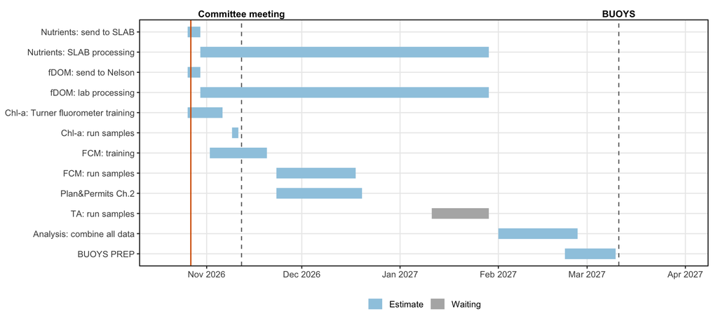

```r
# ---- edit dates here as plans change ----
# status: "Planned" = date known, "Estimate" = my best guess, "Waiting" = depends on something outside my control
plan <- tribble(
  ~task,                               ~start,        ~end,          ~status,
  "Nutrients: send to SLAB",           "2026-10-26",  "2026-10-30",  "Estimate",
  "Nutrients: SLAB processing",        "2026-10-30",  "2027-01-29",  "Estimate",   # ~3 months
  "fDOM: send to Nelson",              "2026-10-26",  "2026-10-30",  "Estimate",
  "fDOM: lab processing",              "2026-10-30",  "2027-01-29",  "Estimate",   # ~3 months
  "Chl-a: Turner fluorometer training","2026-10-26",  "2026-11-06",  "Estimate",
  "Chl-a: run samples",                "2026-11-09",  "2026-11-11",  "Estimate",   # 2-3 days after training
  "FCM: training",                     "2026-11-02",  "2026-11-20",  "Estimate",
  "FCM: run samples",                  "2026-11-23",  "2026-12-18",  "Estimate",   # time unknown - update after training
  "Plan&Permits Ch.2",                 "2026-11-23",  "2026-12-20",  "Estimate",
  "TA: run samples",                   "2027-01-11",  "2027-01-29",  "Waiting",    # when titrant arrives
  "Analysis: combine all data",        "2027-02-01",  "2027-02-26",  "Estimate",
  "BUOYS PREP",                        "2027-02-22",  "2027-03-10",  "Estimate"
) %>%
  mutate(across(c(start, end), as.Date),
         task = factor(task, levels = rev(task)))   # keep the order above, top to bottom

milestones <- tribble(
  ~event,                    ~date,
  "Committee meeting",       "2026-11-12",
  "BUOYS", "2027-03-11"
) %>% mutate(date = as.Date(date))

ggplot(plan) +
  geom_vline(data = milestones, aes(xintercept = date), linetype = "dashed", color = "grey40") +
  geom_text(data = milestones, aes(x = date, y = Inf, label = event),
            vjust = -0.4, size = 3.3, fontface = "bold") +
  geom_segment(aes(x = start, xend = end, y = task, yend = task, color = status), linewidth = 5) +
  geom_vline(xintercept = Sys.Date(), color = "#D55E00", linewidth = 0.6) +   # today
  scale_color_manual(values = c(Planned = "#0072B2", Estimate = "#9ECAE1", Waiting = "grey70"),
                     breaks = c("Planned", "Estimate", "Waiting")) +
  scale_x_date(date_breaks = "1 month", date_labels = "%b %Y",
               limits = as.Date(c("2026-10-19", "2027-03-31"))) +
  coord_cartesian(clip = "off") +
  theme_bw(base_size = 11) +
  labs(x = NULL, y = NULL, color = NULL) +
  theme(legend.position = "bottom", panel.grid.minor = element_blank(),
        plot.margin = margin(t = 20, r = 10, b = 5, l = 5))
```

## 4. Respirometry processing

Rates are calculated in two steps:

1. `scripts/respirometry/respo_LoLinR.R`: run **once per sample day**. Cuts each raw O₂ file to its dark and light windows (from `mpw_respo_meta.csv`), drops the acclimation period, thins the data, and fits LoLinR local regressions (Olito et al. 2017). Saves `processed/mpw_RespoR_D#.csv` and diagnostic PDFs in `output/mpw/respirometry/D#/`. Slow if long day and thinned to every 10th row.
2. `scripts/respirometry/respo_rates_plots.R`: converts slopes to µmol O₂ hr⁻¹ using chamber volume, calculates respiration, net and gross photosynthesis, and makes plots.

```r
tribble(
  ~day, ~thin_n, ~acclim_sec, ~note,
  "D1", 10, 1800, "",
  "D2", 10, 1800, "",
  "D3", 20, 1800, "rerun 10/21 (session closed before saving), thinned to every 20th",
  "D4", 10, 1800, "",
  "D5", 20, 1800,    "merged export from problematic run;long run so thinned every 20th",
  "D6", 20, 1800, "rerun 10/21 (session closed before saving), thinned to every 20th",
) %>% kable(caption = "Processing settings per day. thin_n = keep every Nth row; acclim_sec = seconds dropped at the start of each phase")
```

Processing settings per day. thin_n = keep every Nth row; acclim_sec = seconds dropped at the start of each phase

| day | thin_n | acclim_sec | note |
| --- | --- | --- | --- |
| D1 | 10 | 1800 |  |
| D2 | 10 | 1800 |  |
| D3 | 20 | 1800 | rerun 10/21 (session closed before saving), thinned to every 20th |
| D4 | 10 | 1800 |  |
| D5 | 20 | 1800 | merged export from problematic run;long run so thinned every 20th |
| D6 | 20 | 1800 | rerun 10/21 (session closed before saving), thinned to every 20th |

**Note**

Days were processed with different thinning (every 10th vs 20th row). A test on D5 showed slopes barely change between the two, but before publishing, all days should be rerun with the same settings.

```r
# the key lines inside the loop in respo_LoLinR.R (shown, not run)
data <- Respo.Data1 %>%
  filter(Time >= start_time & Time <= stop_time) %>%   # dark or light window from metadata
  arrange(Time) %>%
  mutate(t_sec = as.numeric(difftime(Time, first(Time), units = "secs"))) %>%
  filter(t_sec > acclim_sec) %>%                        # drop acclimation period
  filter(row_number() %% thin_n == 0)                   # thin the data

rankLocReg(xall = data$t_sec, yall = data$Value, alpha = 0.2, method = "pc")  # LoLinR fit
```

## 5. Quality control

**Rule for now:** a sample is excluded if O₂ *rises* in the dark (respiration < 0), which is not biologically possible. Additionally if the probe clearly failed (bad calibration D1). Excluded samples are marked in the `exclude` column of `mpw_respo_meta.csv` and will be revisited.

```r
excluded %>% count(exclude, name = "samples") %>%
  kable(caption = "Samples excluded so far, by reason")
```

Samples excluded so far, by reason

| exclude | samples |
| --- | --- |
| R up | 52 |
| probe failure | 1 |

### Failures by instrument

```r
resp <- RespoR_PR %>%
  filter(PR == "Respiration", !str_detect(sample_ID, "BLK")) %>%
  mutate(R_up = Values < 0,
         device = device_of(chamber_channel))

resp %>%
  group_by(device) %>%
  summarise(samples = n(), n_R_up = sum(R_up), percent = round(100 * mean(R_up))) %>%
  kable(caption = "Samples where O2 rose in the dark, by instrument (blanks not included)")
```

Samples where O2 rose in the dark, by instrument (blanks not included)

| device | samples | n_R_up | percent |
| --- | --- | --- | --- |
| Oxy-10 (ch 13-22) | 48 | 34 | 71 |
| Oxy-4 #082 (ch 5-8) | 23 | 6 | 26 |
| Oxy-4 #087 (ch 1-4) | 20 | 3 | 15 |
| Oxy-4 #100 (ch 9-12) | 24 | 5 | 21 |

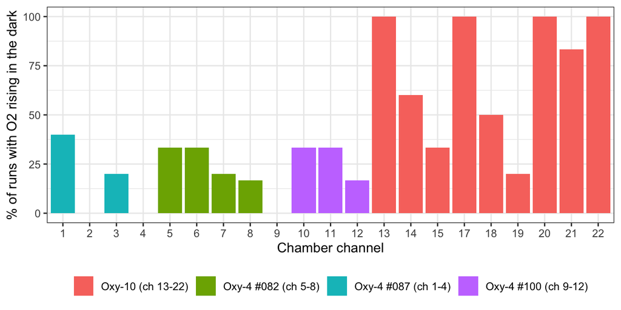

```r
resp %>%
  group_by(chamber_channel, device) %>%
  summarise(percent_R_up = 100 * mean(R_up), n = n(), .groups = "drop") %>%
  ggplot(aes(x = factor(chamber_channel), y = percent_R_up, fill = device)) +
  geom_col() +
  labs(x = "Chamber channel", y = "% of runs with O2 rising in the dark", fill = NULL) +
  theme_bw() +
  theme(legend.position = "bottom")
```

**What this shows:** 34 of the 48 sample failures were on the Oxy-10 (channels 13–22), plus all 4 working blanks, which were also on the Oxy-10 (52 “R up” in total). It reads high in both phases: the median dark slope on the Oxy-10 is about +0.13 µmol L⁻¹ h⁻¹ versus about −0.2 on the Oxy-4s. Every blank was on the Oxy-10, and all of them rose in the dark (BLK1’s probe failed outright). The Oxy-4 failures were mostly runs where the chamber cooled slightly during the dark phase.

```r
RespoR_PR %>%
  filter(str_detect(sample_ID, "BLK")) %>%
  select(run_block, sample_ID, chamber_channel, PR, Values) %>%
  pivot_wider(names_from = PR, values_from = Values) %>%
  mutate(across(where(is.double), ~ signif(.x, 3))) %>%
  kable(caption = "Blanks (umol O2/hr). All on the Oxy-10; BLK1 = probe failure")
```

Blanks (umol O2/hr). All on the Oxy-10; BLK1 = probe failure

| run_block | sample_ID | chamber_channel | Respiration | NetPhoto | GrossPhoto |
| --- | --- | --- | --- | --- | --- |
| D1 | MPW_BLK1 | 22 | 42600.000 | -1.00e+05 | -5.76e+04 |
| D2 | MPW_BLK2 | 17 | -0.416 | 3.04e-01 | -1.11e-01 |
| D3 | MPW_BLK3 | 14 | -0.541 | 3.16e-01 | -2.26e-01 |
| D4 | MPW_BLK4 | 20 | -0.261 | 1.95e-01 | -6.62e-02 |
| D5 | MPW_BLK5 | 19 | -0.606 | 8.87e-02 | -5.17e-01 |

## 6. Results so far

**Warning**

Preliminary. Excluded samples are removed, rates are **not** blank-corrected, and most remaining data come from the Oxy-4s (see QC).

```r
sgd_cutoff_m <- 10   # lagoon samples closer than this to the SGD = "near_SGD", the rest = "T"

plot_data <- RespoR_PR %>%
  left_join(SampleMeta %>% select(sample_ID, habitat, dist_to_sgd_m, time_collected), by = "sample_ID") %>%
  filter(habitat != "blank") %>%
  filter(!sample_ID %in% excluded$sample_ID) %>%
  mutate(habitat_sgd = case_when(habitat == "lagoon" & dist_to_sgd_m <  sgd_cutoff_m ~ "near_SGD",
                                 habitat == "lagoon" & dist_to_sgd_m >= sgd_cutoff_m ~ "T",
                                 habitat == "cove"  ~ "C",
                                 habitat == "ocean" ~ "O"),
         habitat_sgd = factor(habitat_sgd, levels = c("near_SGD", "T", "C", "O")),
         PR = factor(PR, levels = c("Respiration", "NetPhoto", "GrossPhoto"),
                     labels = c("Respiration", "Net photosynthesis", "Gross photosynthesis")))
```

### Rates by habitat

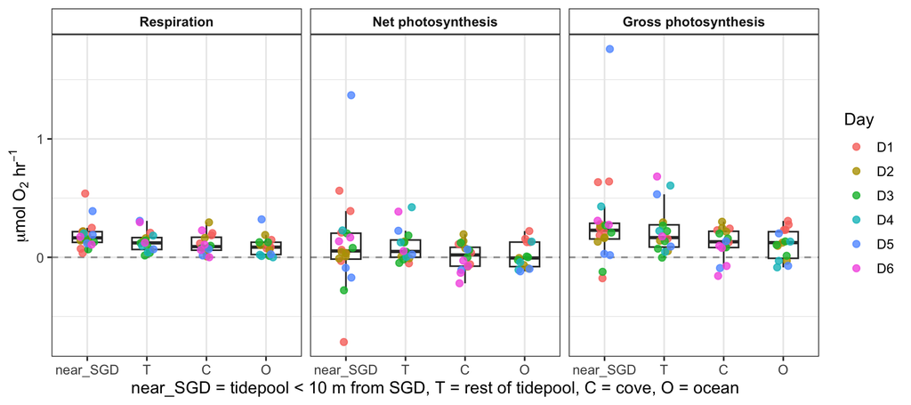

```r
plot_data %>%
  ggplot(aes(x = habitat_sgd, y = Values)) +
  geom_hline(yintercept = 0, linetype = "dashed", color = "grey60") +
  geom_boxplot(outlier.shape = NA, width = 0.5) +
  geom_jitter(aes(color = run_block), width = 0.12, alpha = 0.8, size = 2) +
  facet_wrap(~PR, nrow = 1) +
  theme_bw(base_size = 12) +
  labs(x = paste0("near_SGD = tidepool < ", sgd_cutoff_m, " m from SGD, T = rest of tidepool, C = cove, O = ocean"),
       y = expression(paste(mu, "mol O"[2], " hr"^-1)), color = "Day") +
  theme(strip.background = element_rect(fill = "white"), strip.text = element_text(face = "bold"))
```

```r
# one row per sample, with respiration, net and gross photosynthesis as columns
rates_wide <- RespoR_PR %>%
  filter(!sample_ID %in% excluded$sample_ID) %>%              # drop excluded samples
  select(sample_ID, PR, Values) %>%
  pivot_wider(names_from = PR, values_from = Values) %>%
  left_join(SampleMeta, by = "sample_ID") %>%                 # add habitat, salinity, day, etc.
  filter(habitat != "blank") %>%
  mutate(habitat = factor(habitat, levels = c("lagoon", "cove", "ocean")))

# median and interquartile range (middle 50% of samples) for each habitat
rates_wide %>%
  group_by(habitat) %>%
  summarise(n = n(),
            across(c(Respiration, NetPhoto, GrossPhoto),
                   ~ sprintf("%.2f (%.2f to %.2f)", median(.x), quantile(.x, 0.25), quantile(.x, 0.75)))) %>%
  kable(caption = "Median rate (interquartile range) by habitat, umol O2/hr. Excluded samples removed.")
```

Median rate (interquartile range) by habitat, umol O2/hr. Excluded samples removed.

| habitat | n | Respiration | NetPhoto | GrossPhoto |
| --- | --- | --- | --- | --- |
| lagoon | 36 | 0.14 (0.09 to 0.20) | 0.05 (-0.01 to 0.19) | 0.21 (0.12 to 0.28) |
| cove | 16 | 0.09 (0.06 to 0.17) | 0.02 (-0.07 to 0.08) | 0.13 (0.08 to 0.22) |
| ocean | 15 | 0.09 (0.02 to 0.13) | -0.01 (-0.08 to 0.13) | 0.12 (-0.01 to 0.22) |

### Rates vs measured salinity (lagoon)

Salinity measured in each sample is used here as the groundwater tracer (lower salinity = more groundwater), instead of distance on the map.

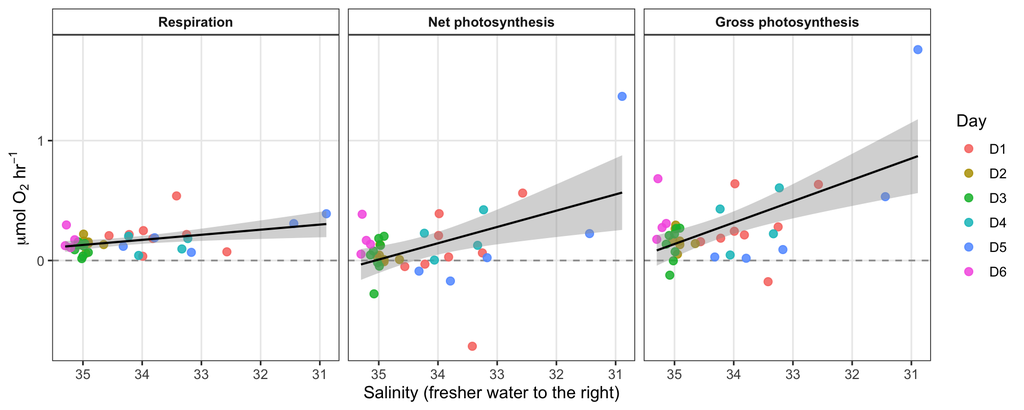

```r
rates_wide %>%
  filter(habitat == "lagoon", !is.na(salinity)) %>%
  pivot_longer(c(Respiration, NetPhoto, GrossPhoto), names_to = "PR", values_to = "Values") %>%
  mutate(PR = factor(PR, levels = c("Respiration", "NetPhoto", "GrossPhoto"),
                     labels = c("Respiration", "Net photosynthesis", "Gross photosynthesis")),
         day = paste0("D", day)) %>%
  ggplot(aes(x = salinity, y = Values)) +
  geom_hline(yintercept = 0, linetype = "dashed", color = "grey60") +
  geom_point(aes(color = day), size = 2.3, alpha = 0.85) +
  geom_smooth(method = "lm", color = "black", linewidth = 0.7) +   # one straight-line trend for all days together
  facet_wrap(~PR, nrow = 1) +
  scale_x_reverse() +                                              # fresher water on the right
  theme_bw(base_size = 12) +
  labs(x = "Salinity (fresher water to the right)", y = expression(paste(mu, "mol O"[2], " hr"^-1)), color = "Day") +
  theme(strip.background = element_rect(fill = "white"), strip.text = element_text(face = "bold"),
        panel.grid.minor = element_blank())
```

### Rates vs salinity, pH and DO (all kept samples)

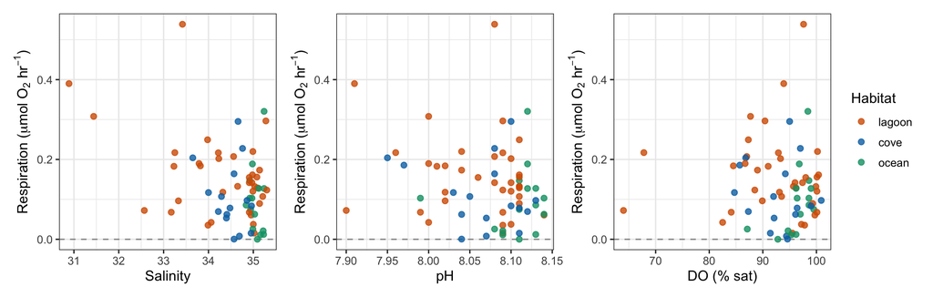

```r
library(patchwork)

habitat_colors <- c(lagoon = "#D55E00", cove = "#0072B2", ocean = "#009E73")   # same colours as earlier plots

# one scatter plot: x = field measurement, y = rate, colour = habitat
scatter_one <- function(x, xlab, y, ylab) {
  rates_wide %>%
    mutate(habitat = factor(habitat, levels = c("lagoon", "cove", "ocean"))) %>%
    ggplot(aes(x = .data[[x]], y = .data[[y]], color = habitat)) +
    geom_hline(yintercept = 0, linetype = "dashed", color = "grey60") +
    geom_point(size = 2, alpha = 0.8) +
    scale_color_manual(values = habitat_colors) +
    theme_bw(base_size = 12) +
    labs(x = xlab, y = ylab, color = "Habitat")
}

r_lab  <- expression(paste("Respiration (", mu, "mol O"[2], " hr"^-1, ")"))
np_lab <- expression(paste("Net photosynthesis (", mu, "mol O"[2], " hr"^-1, ")"))
gp_lab <- expression(paste("Gross photosynthesis (", mu, "mol O"[2], " hr"^-1, ")"))

# Respiration
scatter_one("salinity", "Salinity", "Respiration", r_lab) +
  scatter_one("pH", "pH", "Respiration", r_lab) +
  scatter_one("DO_pct", "DO (% sat)", "Respiration", r_lab) +
  plot_layout(guides = "collect")      # one shared legend
```

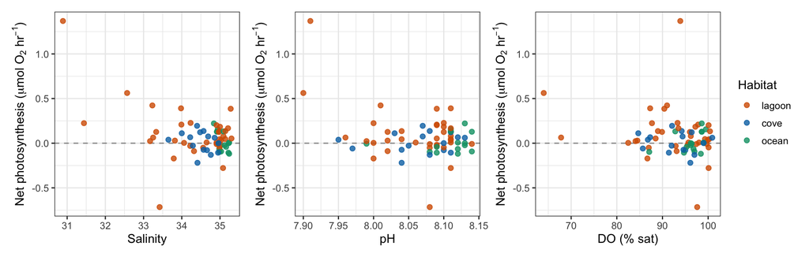

```r
# Net photosynthesis
scatter_one("salinity", "Salinity", "NetPhoto", np_lab) +
  scatter_one("pH", "pH", "NetPhoto", np_lab) +
  scatter_one("DO_pct", "DO (% sat)", "NetPhoto", np_lab) +
  plot_layout(guides = "collect")
```

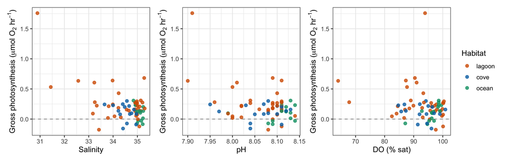

```r
# Gross photosynthesis
scatter_one("salinity", "Salinity", "GrossPhoto", gp_lab) +
  scatter_one("pH", "pH", "GrossPhoto", gp_lab) +
  scatter_one("DO_pct", "DO (% sat)", "GrossPhoto", gp_lab) +
  plot_layout(guides = "collect")
```

## 7. Questions

1. **Oxy-10 drift:** 71% of Oxy-10 sample runs (34 of 48) show O₂ rising in the dark, and so do all the blanks. Known issue with this unit? Correct with the blanks, or treat as lost and fix the instrument before the next run?

## Change log

*One dated line per work session: what was done and why.*

- 2026-10-18: Adapted the respo script for MPW; run one day at a time. D1 run.
- 2026-10-20: D1–D4, D6 run. D5 hung (very long light phase): added `acclim_sec` and `thin_n` settings; D5 run with 0 and 20.
- 2026-10-21: D3 and D6 rerun at every 20th row (session closed before saving). Found that most dark-phase failures are on the Oxy-10. Added `exclude` column to `mpw_respo_meta.csv` (52 “R up” + BLK1 probe failure). Split the script into `respo_LoLinR.R` and `respo_rates_plots.R`. Filled real GPS coordinates for 16 samples. Recomputed distance to SGD for all samples (nearest SGD polygon or seep point, from `MPW_map.kmz`); every habitat now matches its zone on the map. Added tides file.
- 2026-10-27: Made pH, salinity, DO plots. Moved exploratory plots to lab_meeting_code